# PA1_template

# Introduction

It is now possible to collect a large amount of data about personal movement using activity monitoring devices such as a Fitbit, Nike Fuelband, or Jawbone Up. These type of devices are part of the “quantified self” movement - a group of enthusiasts who take measurements about themselves regularly to improve their health, to find patterns in their behavior, or because they are tech geeks. But these data remain under-utilized both because the raw data are hard to obtain and there is a lack of statistical methods and software for processing and interpreting the data.

This assignment makes use of data from a personal activity monitoring device. This device collects data at 5 minute intervals through out the day. The data consists of two months of data from an anonymous individual collected during the months of October and November, 2012 and include the number of steps taken in 5 minute intervals each day.

The analysis uses the dplyr and ggplot2 packages.

```r
library(dplyr)
```

```r
library(ggplot2)
```

## Load and Process the Data

1. Download and unzip the the orignal data:

```r
download.file(url = "https://d396qusza40orc.cloudfront.net/repdata%2Fdata%2Factivity.zip", destfile = "dataset.zip")
unzip("dataset.zip")
```

2. Read the data and view summary stats:

```r
activityraw <- read.csv(file = "activity.csv", na.strings = "NA", colClasses = c(NA,"Date",NA))
summary(activityraw)
```

```
##      steps             date               interval
##  Min.   :  0.00   Min.   :2012-10-01   Min.   :   0.0
##  1st Qu.:  0.00   1st Qu.:2012-10-16   1st Qu.: 588.8
##  Median :  0.00   Median :2012-10-31   Median :1177.5
##  Mean   : 37.38   Mean   :2012-10-31   Mean   :1177.5
##  3rd Qu.: 12.00   3rd Qu.:2012-11-15   3rd Qu.:1766.2
##  Max.   :806.00   Max.   :2012-11-30   Max.   :2355.0
##  NA's   :2304
```

```r
str(activityraw)
```

```
## 'data.frame':    17568 obs. of  3 variables:
##  $ steps   : int  NA NA NA NA NA NA NA NA NA NA ...
##  $ date    : Date, format: "2012-10-01" "2012-10-01" ...
##  $ interval: int  0 5 10 15 20 25 30 35 40 45 ...
```

## What is the mean total number of steps taken per day?

```r
meandays <- group_by(activityraw, date)
meandays <- summarize(meandays, steps = mean(steps, na.rm = TRUE))
mean <- summarize(meandays, steps = mean(steps, na.rm = TRUE))
median <- summarize(meandays, steps = median(steps, na.rm = TRUE))
```

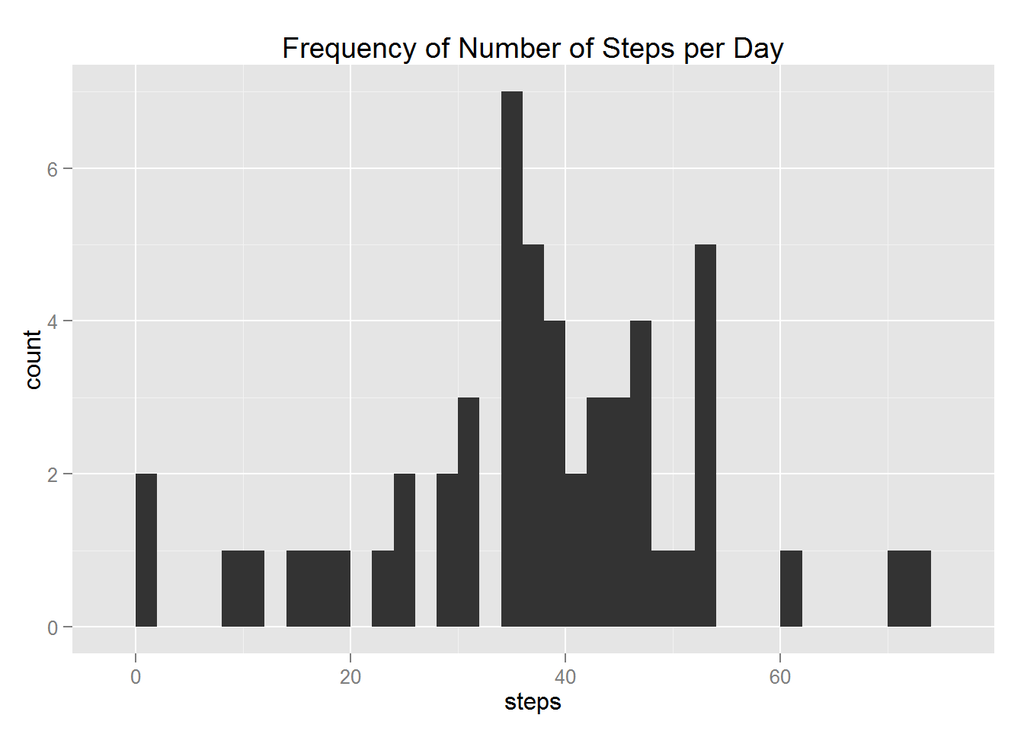

```r
qplot(steps, data = meandays, binwidth = 2, main = "Frequency of Number of Steps per Day")
```

## What is the average daily activity pattern?

1. Let’s see a time series of steps over the 5-minute intervals:

```r
avgintervalalldays <- group_by(activityraw, interval)
avgintervalalldays <- summarize(avgintervalalldays, mean(steps, na.rm = TRUE))
# Rename column two to "avgsteps"
names(avgintervalalldays)[2] <- "avgsteps"

str(avgintervalalldays)
```

```
## Classes 'tbl_df', 'tbl' and 'data.frame':    288 obs. of  2 variables:
##  $ interval: int  0 5 10 15 20 25 30 35 40 45 ...
##  $ avgsteps: num  1.717 0.3396 0.1321 0.1509 0.0755 ...
```

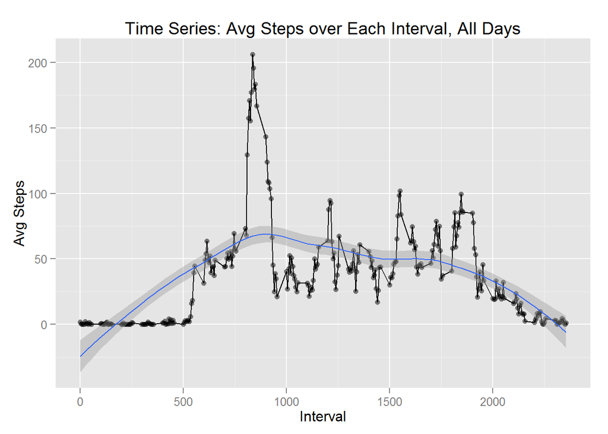

```r
g <- ggplot(avgintervalalldays, aes(interval, avgsteps)) + xlab("Interval") + ylab("Avg Steps") + ggtitle("Time Series: Avg Steps over Each Interval, All Days")
g + geom_point(alpha = 1/2) + geom_line() + geom_smooth(method = "loess")
```

```r
maxsteps <- max(avgintervalalldays$avgsteps, na.rm = TRUE)

agg <- aggregate(avgsteps ~ interval, avgintervalalldays, max)
maxinterval <- merge(agg, avgintervalalldays)
maxinterval <- filter(maxinterval, avgsteps == maxsteps)
maxinterval <- maxinterval[1,1]
```

2. The interval with the maximum number of steps averaged over all the days is **835**, with a maximum number of average steps of **206.1698113** during that interval.

## Imputing Missing Values

Missing days may introduce bias into some calculations or summaries of the data.

```r
missingsteps <- sum(is.na(activityraw))
```

1. There are **2304** intervals with no steps recorded (ie. NA values).
2. We will replace NAs with the average steps over the interval for all days.

3.1. Merge oringal data and average steps by interval data:

```r
merged <- merge(activityraw,avgintervalalldays,by.x="interval",by.y="interval")
head(merged, 3)
```

```
##   interval steps       date avgsteps
## 1        0    NA 2012-10-01 1.716981
## 2        0     0 2012-11-23 1.716981
## 3        0     0 2012-10-28 1.716981
```

3.2. Replace NA values with average steps per interval.

```r
naindex <- is.na(merged$steps)
merged$steps[naindex] <-merged$avgsteps[naindex]
head(merged, 3)
```

```
##   interval    steps       date avgsteps
## 1        0 1.716981 2012-10-01 1.716981
## 2        0 0.000000 2012-11-23 1.716981
## 3        0 0.000000 2012-10-28 1.716981
```

```r
meandays <- group_by(merged, date)
meandays <- summarize(meandays, steps = mean(steps, na.rm = TRUE))
mean <- summarize(meandays, steps = mean(steps, na.rm = TRUE))
median <- summarize(meandays, steps = median(steps, na.rm = TRUE))
```

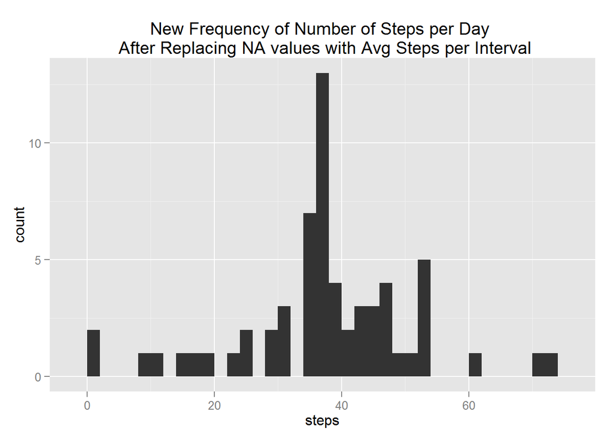

```r
qplot(steps, data = meandays, binwidth = 2, main = "New Frequency of Number of Steps per Day \n After Replacing NA values with Avg Steps per Interval")
```

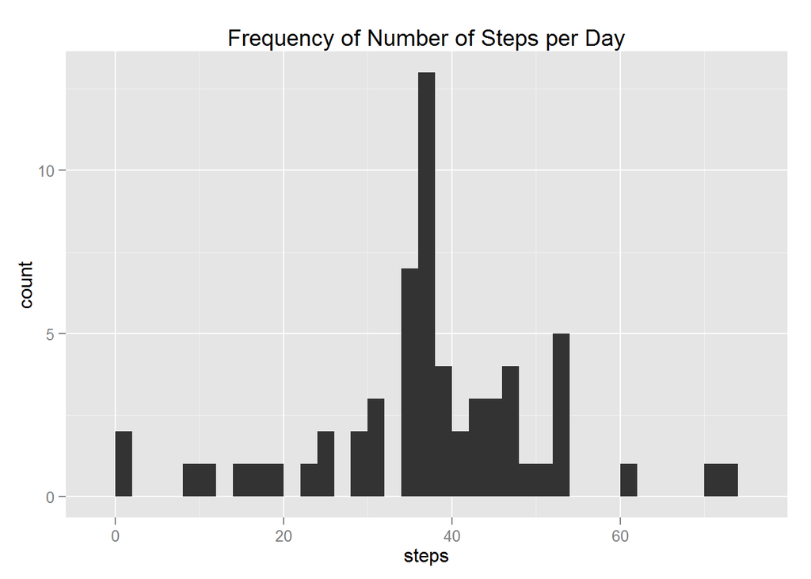

```r
qplot(steps, data = meandays, binwidth = 2, main = "Frequency of Number of Steps per Day")
```

## Are there differences in activity patterns between weekdays and weekends?

```r
weekendlist <- c('Saturday','Sunday')
merged$weekend <- factor((weekdays(merged$date) %in% weekendlist), levels=c(TRUE, FALSE), labels = c('weekend','weekday'))
head(merged,10)
```

```
##    interval    steps       date avgsteps weekend
## 1         0 1.716981 2012-10-01 1.716981 weekday
## 2         0 0.000000 2012-11-23 1.716981 weekday
## 3         0 0.000000 2012-10-28 1.716981 weekend
## 4         0 0.000000 2012-11-06 1.716981 weekday
## 5         0 0.000000 2012-11-24 1.716981 weekend
## 6         0 0.000000 2012-11-15 1.716981 weekday
## 7         0 0.000000 2012-10-20 1.716981 weekend
## 8         0 0.000000 2012-11-16 1.716981 weekday
## 9         0 0.000000 2012-11-07 1.716981 weekday
## 10        0 0.000000 2012-11-25 1.716981 weekend
```

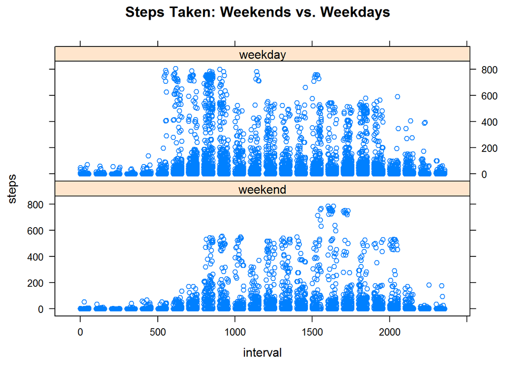

```r
library(lattice)
xyplot(steps ~ interval | weekend, data = merged, layout = c(1, 2), main="Steps Taken: Weekends vs. Weekdays")
```